# Reading & Cleaning Data

## rename with regex

**Note to teachers:** This is a good opportunity to let the students play with the code on their own to get these solutions.

Lets first drop out the `\n`

```r
names(crime) %>%
  gsub("\n", "_", .)
```

```
 [1] "State"                                "University/College"
 [3] "Campus"                               "Student_enrollment1"
 [5] "Violent_crime"                        "Murder and_nonnegligent_manslaughter"
 [7] "Rape_(revised_definition)2"           "Rape_(legacy_definition)3"
 [9] "Robbery"                              "Aggravated_assault"
[11] "Property_crime"                       "Burglary"
[13] "Larceny-_theft"                       "Motor_vehicle_theft"
[15] "Arson4"
```

When renaming colnames in batch like this, I like to string together all my regexes and monitor the output as I add them on to make sure things make sense, then I’ll go back and save the changes once I’m happy with the results. We’ll take that approach here by continually adding new `gsub` commands until we get colnames we like.

Now that we’ve solved the newline issue, what other issues exist? Take a look at the `/`. This is a bad character in a colname because R needs to escape it to access it. Let’s change it to ‘.’

While we’re at it, let’s also drop out the `-` because this means “subtract” in R, so it also is a bad character for colnames. We’ll just delete it.

There’s also some spaces in the colnames (look carefully!). We don’t want those either, so change them to “_“.

```r
names(crime) %>%
  gsub("\n", "_", .) %>%
  gsub("/", ".", .) %>%
  # replacing for an empty string will delete a character/pattern
  gsub("-", "", .) %>%
  gsub(" ", "_", .)
```

```
 [1] "State"                                "University.College"
 [3] "Campus"                               "Student_enrollment1"
 [5] "Violent_crime"                        "Murder_and_nonnegligent_manslaughter"
 [7] "Rape_(revised_definition)2"           "Rape_(legacy_definition)3"
 [9] "Robbery"                              "Aggravated_assault"
[11] "Property_crime"                       "Burglary"
[13] "Larceny_theft"                        "Motor_vehicle_theft"
[15] "Arson4"
```

You’ll also notice that some columns end in numbers. These aren’t descriptive, so let’s delete them too.

We can use the special regex character `\d` which means “match any number”. Because R is weird, you have to escape the first `\` when you call `\d` in regex’s. This is often true for other regex characters like ‘.’ (match any character) which has to be `\\.` in R. This might not make sense right now, but if you work more with regex’s later, keep this in mind!

```r
names(crime) %>%
  gsub("\n", "_", .) %>%
  gsub("/", ".", .) %>%
  gsub("-", "", .) %>%
  gsub(" ", "_", .) %>%
  gsub("\\d", "", .)
```

```
 [1] "State"                                "University.College"
 [3] "Campus"                               "Student_enrollment"
 [5] "Violent_crime"                        "Murder_and_nonnegligent_manslaughter"
 [7] "Rape_(revised_definition)"            "Rape_(legacy_definition)"
 [9] "Robbery"                              "Aggravated_assault"
[11] "Property_crime"                       "Burglary"
[13] "Larceny_theft"                        "Motor_vehicle_theft"
[15] "Arson"
```

Next, let’s get rid of the parentheses. We can use another regex pattern `[]` which will match any characters inside the square brackets to delete both “(” and “)”.

```r
names(crime) %>%
  gsub("\n", "_", .) %>%
  gsub("/", ".", .) %>%
  gsub("-", "", .) %>%
  gsub(" ", "_", .) %>%
  gsub("\\d", "", .) %>%
  gsub("[()]", "", .)
```

```
 [1] "State"                                "University.College"
 [3] "Campus"                               "Student_enrollment"
 [5] "Violent_crime"                        "Murder_and_nonnegligent_manslaughter"
 [7] "Rape_revised_definition"              "Rape_legacy_definition"
 [9] "Robbery"                              "Aggravated_assault"
[11] "Property_crime"                       "Burglary"
[13] "Larceny_theft"                        "Motor_vehicle_theft"
[15] "Arson"
```

Finally, let’s get rid of the capitalization in the colnames to make it consistent. We’ll convert everything to lowercase with the function `tolower()`.

```r
names(crime) %>%
  gsub("\n", "_", .) %>%
  gsub("/", ".", .) %>%
  gsub("-", "", .) %>%
  gsub(" ", "_", .) %>%
  gsub("\\d", "", .) %>%
  gsub("[()]", "", .) %>%
  tolower()
```

```
 [1] "state"                                "university.college"
 [3] "campus"                               "student_enrollment"
 [5] "violent_crime"                        "murder_and_nonnegligent_manslaughter"
 [7] "rape_revised_definition"              "rape_legacy_definition"
 [9] "robbery"                              "aggravated_assault"
[11] "property_crime"                       "burglary"
[13] "larceny_theft"                        "motor_vehicle_theft"
[15] "arson"
```

Now save the new names with `%<>%` which will send the final output back as input.

```r
names(crime) %<>%
  gsub("\n", "_", .) %>%
  gsub("/", ".", .) %>%
  gsub("-", "", .) %>%
  gsub(" ", "_", .) %>%
  gsub("\\d", "", .) %>%
  gsub("[()]", "", .) %>%
  tolower()
```

```r
names(crime)
```

```
 [1] "state"                                "university.college"
 [3] "campus"                               "student_enrollment"
 [5] "violent_crime"                        "murder_and_nonnegligent_manslaughter"
 [7] "rape_revised_definition"              "rape_legacy_definition"
 [9] "robbery"                              "aggravated_assault"
[11] "property_crime"                       "burglary"
[13] "larceny_theft"                        "motor_vehicle_theft"
[15] "arson"
```

For more reading on regex’s check: Regex cheatsheet

# Fill in missing values

Take a look at the `state` and `university.college` columns. Each row labeled as `NA` takes the value of the previously assigned row. We need a way to fill these values down.

```r
crime
```

| state | university.college | campus | student_enrollment | violent_crime | murder_and_nonnegligent_manslaughter | rape_revised_definition | rape_legacy_definition | robbery | aggravated_assault | property_crime | burglary | larceny_theft | motor_vehicle_theft | arson |
| --- | --- | --- | --- | --- | --- | --- | --- | --- | --- | --- | --- | --- | --- | --- |
| ALABAMA | Alabama A&M University | NA | 5333 | 12 | 0 | 2 | NA | 3 | 7 | 78 | 1 | 75 | 2 | NA |
| NA | Jacksonville State University | NA | 8659 | 7 | 0 | 0 | NA | 0 | 7 | 59 | 9 | 50 | 0 | NA |
| NA | Samford University | NA | 4933 | 3 | 0 | 0 | NA | 0 | 3 | 46 | 8 | 34 | 4 | NA |
| NA | Tuskegee University | NA | 3103 | 5 | 0 | 0 | NA | 1 | 4 | 112 | 12 | 97 | 3 | NA |
| NA | University of Alabama: | Birmingham | 18698 | 24 | 0 | 2 | NA | 3 | 19 | 395 | 5 | 379 | 11 | NA |
| NA | NA | Huntsville | 7348 | 10 | 0 | 1 | NA | 1 | 8 | 73 | 18 | 55 | 0 | NA |
| NA | NA | Tuscaloosa | 36047 | 15 | 0 | 3 | NA | 9 | 3 | 359 | 36 | 316 | 7 | NA |
| NA | University of South Alabama | NA | 15805 | 21 | 0 | 1 | NA | 3 | 17 | 165 | 28 | 136 | 1 | NA |
| ALASKA | University of Alaska: | Anchorage | 17151 | 4 | 0 | 1 | NA | 0 | 3 | 95 | 4 | 88 | 3 | 0 |
| NA | NA | Fairbanks | 8620 | 3 | 0 | 2 | NA | 0 | 1 | 50 | 3 | 44 | 3 | 0 |

[output cut: 670 more lines]

To do this, we can use the `tidyr` package, whose function `fill()` will do just this:

```r
library(tidyr)
(crime %<>%
  fill(state, university.college))
```

| state | university.college | campus | student_enrollment | violent_crime | murder_and_nonnegligent_manslaughter | rape_revised_definition | rape_legacy_definition | robbery | aggravated_assault | property_crime | burglary | larceny_theft | motor_vehicle_theft | arson |
| --- | --- | --- | --- | --- | --- | --- | --- | --- | --- | --- | --- | --- | --- | --- |
| ALABAMA | Alabama A&M University | NA | 5333 | 12 | 0 | 2 | NA | 3 | 7 | 78 | 1 | 75 | 2 | NA |
| ALABAMA | Jacksonville State University | NA | 8659 | 7 | 0 | 0 | NA | 0 | 7 | 59 | 9 | 50 | 0 | NA |
| ALABAMA | Samford University | NA | 4933 | 3 | 0 | 0 | NA | 0 | 3 | 46 | 8 | 34 | 4 | NA |
| ALABAMA | Tuskegee University | NA | 3103 | 5 | 0 | 0 | NA | 1 | 4 | 112 | 12 | 97 | 3 | NA |
| ALABAMA | University of Alabama: | Birmingham | 18698 | 24 | 0 | 2 | NA | 3 | 19 | 395 | 5 | 379 | 11 | NA |
| ALABAMA | University of Alabama: | Huntsville | 7348 | 10 | 0 | 1 | NA | 1 | 8 | 73 | 18 | 55 | 0 | NA |
| ALABAMA | University of Alabama: | Tuscaloosa | 36047 | 15 | 0 | 3 | NA | 9 | 3 | 359 | 36 | 316 | 7 | NA |
| ALABAMA | University of South Alabama | NA | 15805 | 21 | 0 | 1 | NA | 3 | 17 | 165 | 28 | 136 | 1 | NA |
| ALASKA | University of Alaska: | Anchorage | 17151 | 4 | 0 | 1 | NA | 0 | 3 | 95 | 4 | 88 | 3 | 0 |
| ALASKA | University of Alaska: | Fairbanks | 8620 | 3 | 0 | 2 | NA | 0 | 1 | 50 | 3 | 44 | 3 | 0 |

[output cut: 670 more lines]

## Make a plot with your new tidy data!

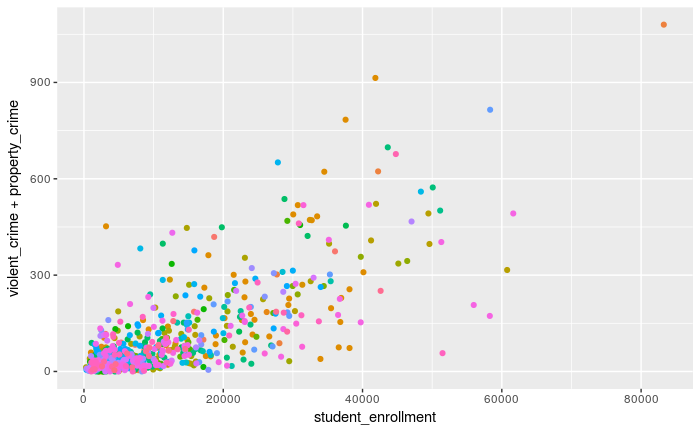

```r
library(ggplot2)
crime %>%
  ggplot(aes(student_enrollment, violent_crime + property_crime)) +
    geom_point(aes(color = state)) +
    theme(legend.position = "none")
```

## Save the cleaned data:

It’s always a good idea to save the clean data for easy sharing with others later.

```r
readr::write_csv(crime, "crime_cleaned.csv")
```